# TP-Visualización, parte 1

Laboratorio de Datos

Guillermo Solovey

9/23/2021

#### Ejercicio 1

A partir del siguiente gráfico, investigar cómo se usa y qué hace el `geom_rug`. Agreguen una capa de geom_rug al plot existente pero que no use el mapeo de species en color.

¿Qué hace `theme_minimal()`? ¿Hay otros themes que se pueden usar?

```r
if("palmerpenguins" %in% rownames(installed.packages()) == FALSE){
  install.packages("palmerpenguins")
}else{
  cat("palmerpenguins ya instalado")
}
```

```
palmerpenguins ya instalado
```

```r
require(ggplot2)
require(palmerpenguins)

penguins <- penguins  # To appear in Environment

filtro.na <- !(is.na(penguins$bill_depth_mm) | is.na(penguins$bill_length_mm))
penguins <- penguins[filtro.na, ]

ggplot(data = penguins, aes(x = bill_depth_mm,
                            y = bill_length_mm,
                            color = species) ) +
  geom_point() +
  geom_rug() +
  theme_minimal()
```

[output not shown]

#### Ejercicio 2

¿Los pinguinos que tienen picos más anchos tienen picos más cortos o más largos?

RTA: Uno podría usar geom_rug() para ver qué especie tiene pico más corto o más largo

Pero como estamos en un contínuo de andos de picos, hablar de “los picos más anchos” queda a interpretación.

Una primer solución, puede ser elegir el 90% del total: * “Todo lo que esté por encima del 90% los datos, son los picos más anchos”

Idea: Graficar para cada 10, 20, …, 90%

```r
filter <- 17

cat("Estadística de los", sum(penguins$bill_depth_mm > filter), ":\n")
```

```
Estadística de los 190 :
```

```r
print(summary(penguins[penguins$bill_depth_mm > filter, c("bill_length_mm", "bill_depth_mm")]))
```

```
 bill_length_mm  bill_depth_mm
 Min.   :33.50   Min.   :17.10
 1st Qu.:38.10   1st Qu.:17.90
 Median :40.95   Median :18.60
 Mean   :42.41   Mean   :18.65
 3rd Qu.:46.40   3rd Qu.:19.20
 Max.   :58.00   Max.   :21.50
```

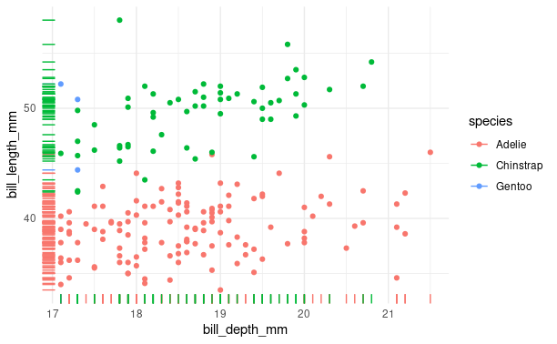

```r
ggplot(data = penguins[penguins$bill_depth_mm > filter,], aes(x = bill_depth_mm,
                                                              y = bill_length_mm,
                                                              color = species)) +
  geom_point() +

  geom_rug() +
  theme_minimal()
```

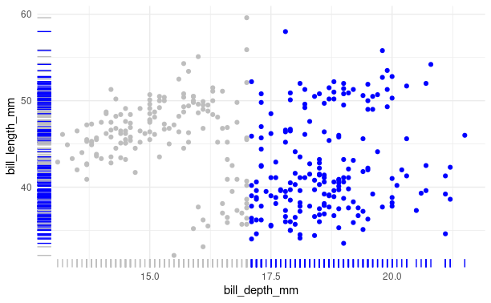

```r
penguins$Color <- ifelse(penguins$bill_depth_mm > filter, "blue", "gray")

ggplot(data = penguins, aes(x = bill_depth_mm,
                            y = bill_length_mm,
                            color = Color)) +
  geom_point() +
  scale_color_identity() +
  geom_rug() +
  theme_minimal()
```

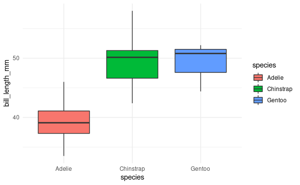

```r
ggplot(data = penguins[penguins$bill_depth_mm > filter,], aes(x = species,
                                                              y = bill_length_mm,
                                                              fill = species)) +
  #geom_point() +
  geom_boxplot() +
  #geom_rug() +
  theme_minimal()
```

```r
NA
NA
```

#### Ejercicio 3

Hacer un violin plot con `geom_violin` y sumen una capa de `geom_boxplot` y `geom_point` o `geom_jitter`

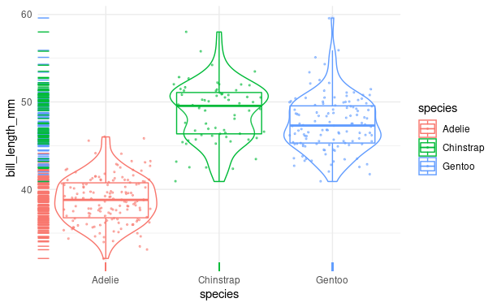

```r
ggplot(data = penguins, aes(x = species,
                            y = bill_length_mm,
                            color = species)) +
  #geom_point() +
  geom_violin() +
  geom_boxplot(alpha=0.1) +
  #geom_point() +
  geom_jitter(alpha=0.5, size=0.5) +
  geom_rug() +
  theme_minimal()
```

#### Ejercicio 4

Repetir alguno de los gráficos que hicieron con los datos de Properati pero esta vez con `ggplot`.

TODO: Probar esto: http://www.r-graph-gallery.com/hexbin-map.html